# Introduction to R and RStudio Day 1 JCSMR Workshop for Students https://github.com/numicator/ANU_R_workshop

Marcin Adamski

17-18 February 2020

This document was created in R Markdown (http://rmarkdown.rstudio.com, http://rmarkdown.rstudio.com/articles_intro.html). R Markdown documents can be easily created in RStudio.

# Learning Objectives for Day 1

- Morning Session:
  - Getting familiar with RStudio
    - Panels in RStudio IDE (Integrated Development Environment)
    - Concept of RStudio Project and creating a new one
    - Create New script file
    - Running script line-by-line
  - Proper commenting of the code
  - Using R as calculator
  - Getting Help
  - Variable and data types
  - naming variables
  - listing and removing variables
  - Logical Operators
  - Homogenous Data Structures
  - Creating and working with vectors
  - Creating and working with matrices
  - Heterogeneous Data Structures
  - Lists
  - Data frames
- Afternoon Session:
  - Reading and writing data files
  - Sub-setting data frames - getting specific rows and columns
  - Summarizing and filtering the data
  - Making plots

# R functions used today

- `#` - starts comment
- `log` - computes natural logarithm
- `log10` - computes base 10 logarithm
- `sin` - computs trigonometric function sinus
- `&` - Logical operator *and*
- `|` - Logical operator *or*
- `!` - Logical operator *not*
- `curve` - draws a curve corresponding to a function over the interval
- `paste` - concatenate vectors after converting to character
- `print` - prints its argument
- `help` - alternatively `?’ returns help on specified topic
- `typeof` - determines the type or storage mode of an object
- `ls` - list the names of the objects
- `rm` - remove objects
- `abs` - computes the absolute value
- `:` - colon operator, generates regular sequences
- `seq` - generates regular sequences
- `c` - combine Values into a Vector or List
- `logical` - creates object of type “logical”
- `numeric` - creates object of type “numeric”
- `character` - creates object of type “character”
- `rep` - replicates the values
- `matrix` - creates a matrix from the given set of values
- `dim` - retrieve or set the dimension of an objec
- `nrow` - number of rows present in an object
- `ncol` - number of columns present in an object
- `det` - calculates the determinant of a matrix
- `solve` - solves the equation a %*% x = b, where b can be either a vector or a matrix.
- `list` - creates a list
- `unlist` - simplifies list to a vector
- `$` - dolar operator, extracts or replaces parts of anoObject
- `[]` - square brackets or index operator, extracts or replaces parts of an object
- `data.frame` - creates data frame object
- `read.table` - reads a file in table format and creates a data frame from it
- `write.table` - writes data frame as a file in table format
- `class` - returns name of the *class* of the object
- `as.<somthing>` - Attempts to convert objest of one type (or class) into another <somthing>, e.g.:
- `as.matrix` - Attempts to convert its argument into a matrix
- `str` - Display the structure of R object
- `head` - Returns first part of an object, e.g. first rows of a data frame
- `tail` - Returns last part of an object, e.g. last rows of a data frame
- `mean` - Calculates arythmentc mean
- `sd` - Calculates standard deviation
- `summary` - Returns summaries of the results of various model fitting functions, e.g. mean, meadian, min, max
- `levels` - Returns levels of a factor variable
- `unique` - Extracts unique elements from vector, matrix, data frame, etc
- `for` - for loop
- `print` - Prints its argument
- `paste` - Concatenate vectors after converting to character
- `plot` - Create a X-Y plot
- `legend` - Adds legend to plot

slides 1-14

# Introduction

## What is R?

**R** is an open source programming language and software environment for statistical computing and graphics that is supported by the R Foundation for Statistical Computing. The R language is widely used among statisticians and data miners for developing statistical software and data analysis.

R and its libraries implement a wide variety of statistical and graphical techniques, including linear and nonlinear modeling, classical statistical tests, time-series analysis, classification, clustering, and others.

R is easily extendable through functions and modules, and the R community is noted for its active contributions in terms of packages.

Many of R’s standard functions are written in R itself, which makes it easy for users to follow the algorithmic choices made. For computationally intensive tasks, C, C++, and Fortran code can be linked and called at run-time (quoted from R - programming language). You can download and install R from [here](https://cran.rstudio.com/).

## What is RStudio?

R Studio (written as RStudio without the space) is a free and open-source Integrated Development Environment (IDE) for R. You can download RStudio from [here](https://www.rstudio.com/products/rstudio/download/#download). RStudio makes our expirience with R easier, but it is not necessary to program in R.

## First steps

### Calculator

Almost all introductory R courses begin from using R as a calculator… We will do the same. Let’s type the formulas (expressions) below and click <Ctrl-ENTER> on PC or <Cmd-ENTER> on Mac.

```r
#now, we use R as a calculator (order of operators is: (), ^, /, *, +, -):
2 + 2
```

```
## [1] 4
```

```r
#we can force the order using parenthesises
3 + 5 * 2 ^ 2
```

```
## [1] 23
```

```r
(1 + 2) * 3
```

```
## [1] 9
```

```r
#or use scientific notation
2e-4 + 1e-6
```

```
## [1] 0.000201
```

We can use bulit-in functions

```r
log(1)
```

```
## [1] 0
```

```r
log10(100)
```

```
## [1] 2
```

```r
sin(1)
```

```
## [1] 0.841471
```

```r
sin(pi)
```

[output not shown]

Our R-calculator can plot!

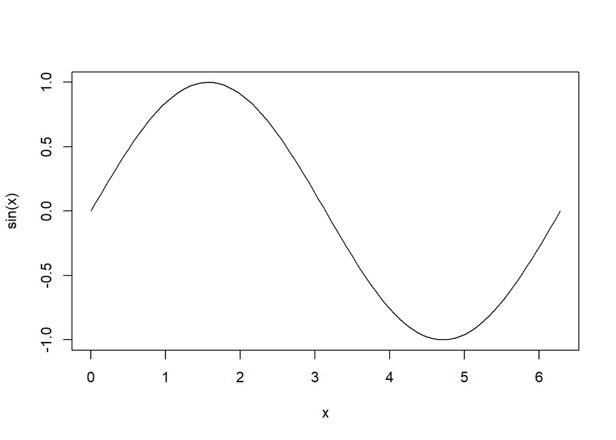

```r
curve(sin, from = 0, to = 2 * pi, n = 100)
```

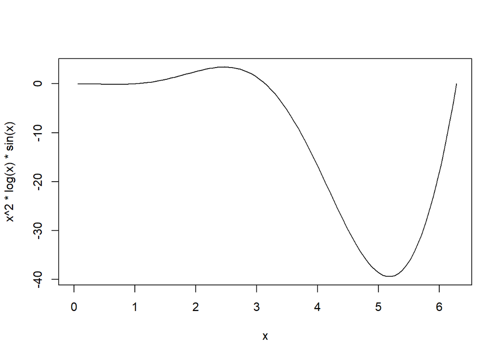

```r
#we can use more complicated expression which uses 'x' as a variable
curve(x^2 * log(x) * sin(x), from = 0, to = 2 * pi, n = 100)
```

R can also work with text

```r
#output text
"Hello World!"
```

```
## [1] "Hello World!"
```

```r
#use bulit-in function print() to print:
print("Hello World!")
```

```
## [1] "Hello World!"
```

```r
#concatenate parts to get one string of text:
print(paste("Answer to", "the Ultimate Question of Life, the Universe, and Everything is", 2^5 + 2^3 + 2^1))
```

```
## [1] "Answer to the Ultimate Question of Life, the Universe, and Everything is 42"
```

### Comment

Have you noticed the code lines starting from the `#` symbol? They are there to comment and explain the code. Comment is an important part of any programming language. In R any line, or part of starting with `#` symbol is treated as a comment and not interpreted. It is a good coding practice to include at the beginning of the code some information about what is the code for, how to use it and who and when wrote it.

```r
######################################################################
#                                                                    #
#   ***     Introduction to R and RStudio, Programming in R     ***  #
#                                                                    #
#   workshop on 17 - 18 February 2020                                #
#                                                                    #
#                                                                    #
#                                            marcin.adamski@anu.edu.au
######################################################################
```

### HELP!!!

How to get help in R:

https://www.r-project.org/help.html

- use function `help()`

```r
help("print")
```

- instead of `help()` you can use `?` shortcut

```r
? print
```

- or use `??` to search the help topics

```r
??print
```

slides 15-19

## Variables and data types

We have already mentioned variables. Now, we will have a closer look at them and the **assignments**.

We can assign numerical values or results of numerical operations:

```r
x <- 1 / 10   #'<-' is an assignment operator; you can enter it with one keystroke as Alt + _ (underscore)
x
```

```
## [1] 0.1
```

```r
x <- 1000   #notice how RStudio updates its description of x on the top right 'Environment' tab
x < - 10    # ***** BE CAREFUL WITH SPACES!!!! *****
```

```
## [1] FALSE
```

```r
x
```

```
## [1] 1000
```

```r
log10(x)
```

```
## [1] 3
```

```r
2 * x
```

```
## [1] 2000
```

```r
isGood    = TRUE
myNumber  = 0.25
myInteger = 2L
myComplex = 3 + 2i
myName    = "Marcin"
```

To check type of the data use the `typeof()` function

```r
typeof(isGood)
```

```
## [1] "logical"
```

```r
typeof(myNumber)
```

```
## [1] "double"
```

```r
typeof(myComplex)
```

```
## [1] "complex"
```

```r
typeof(myName)
```

```
## [1] "character"
```

Not all names of variables are equally good. Variable names can contain letters (upper and lower), numbers (but they can’t start with a digit), underscores, and dots (but if they start from a dot they are ‘hidden’)

```r
#examples of bad variable names
12_from_the_left <- 12     #starting with a number
my name <- "Marcin"        #contains space
me@home <- 2               #contains non-alphanumeric symbol
```

Actually variable names may breake the rules and start with digits and contains spaces if they are enclosed in back-tick marks `` `` ``. E.g.

```r
#examples of bad variable names
`12_from_the_left` <- 12     #starting with a number
`my name` <- "Marcin"        #contains space
`me@home` <- 2               #contains non-alphanumeric symbol
print(`12_from_the_left`)
```

```
## [1] 12
```

```r
print(`my name`)
```

```
## [1] "Marcin"
```

```r
print(`me@home`)
```

```
## [1] 2
```

> Please do us all the favor and do not use the back-tick trick in your code.

We have learnt that a variable is created when a value is assigned to if for the first time.  
But how to list all the variables? And how to delete them?  
To list variables we use the list functions `ls()` (or we can consult the **Environment** panel in RStudio).

```r
ls()
```

```
## [1] "12_from_the_left" "isGood"           "me@home"
## [4] "my name"          "myComplex"        "myInteger"
## [7] "myName"           "myNumber"         "x"
```

To remove a variable we use remove function `rm()` (or use the *broom* icon in the **Environment** panel in RStudio).

```r
rm(myName)

#to remove all variables we use
rm(list = ls())
```

Do you know how the `rm(list = ls())` actually worked?  
How to delete a set of variables using one rm() function?

slides 20-23

## Relational Operators

Relational operators are used to compare objects, e.g. variables, numbers. The result is a logical value - `TRUE` or `FALSE`.

```r
1 == 1   #please note the doube '='
```

```
## [1] TRUE
```

```r
1 == 0
```

```
## [1] FALSE
```

```r
1 < 0
```

```
## [1] FALSE
```

```r
1 >= 0
```

```
## [1] TRUE
```

```r
1.2 == 1.2
```

```
## [1] TRUE
```

Why we should **never** use `==` to compare floating-point numbers:

```r
#often it works... but we may run into problems with float type numbers:
3 / 10 == 0.3
```

```
## [1] TRUE
```

```r
3 * 0.1 == 0.3
```

```
## [1] FALSE
```

```r
#we need to be more creative with floating points:
abs(3 * 0.1 - 0.3) <= 1e-9 #less than some small, acceptable error
```

```
## [1] TRUE
```

> When checking if two floating-points numbers are equal we have to always allow for a small error

## Logical operators

Logical operators are used to carry out Boolean operations like `AND`, `OR`, `NOT`.

`OR` operator, symbol `|`

| A | B | A \| B |
| --- | --- | --- |
| `FALSE` | `FALSE` | `FALSE` |
| `FALSE` | `TRUE` | `TRUE` |
| `TRUE` | `FALSE` | `TRUE` |

`AND` operator, symbol `&`

| A | B | A & B |
| --- | --- | --- |
| `FALSE` | `FALSE` | `FALSE` |
| `FALSE` | `TRUE` | `FALSE` |
| `TRUE` | `FALSE` | `FALSE` |

`NOT` operator, symbol `!`

| A | !A |
| --- | --- |
| `FALSE` | `TRUE` |
| `TRUE` | `FALSE` |

Let’s give the logical opeartors a try:

```r
1 > 0
```

```
## [1] TRUE
```

```r
1 > 2
```

```
## [1] FALSE
```

```r
1 > 0 | 1 > 2
```

```
## [1] TRUE
```

```r
1 > 0 & 1 > 2
```

```
## [1] FALSE
```

```r
!(1 > 0)
```

```
## [1] FALSE
```